# assignment_03

```r
library(dplyr)
```

```r
library(ggplot2)
library(tidytext)
library(forcats)
library(tidyverse)
```

# APIs

Using the NCBI API, look for papers that show up under the term “sars-cov-2 trial vaccine.” Look for the data in the pubmed database, and then retrieve the details of the paper as shown in lab 7. How many papers were you able to find?

```r
# Downloading the website
website <- xml2::read_html("https://pubmed.ncbi.nlm.nih.gov/?term=sars-cov-2+trial+vaccine")

# Finding the counts
counts <- xml2::xml_find_first(website, "/html/body/main/div[9]/div[2]/div[2]/div[1]/div[1]/span")

# Turning it into text
counts <- as.character(counts)

# Extracting the data using regex
stringr::str_extract(counts, "[0-9.,]+")
```

```
## [1] "4,009"
```

There are 4009 papers

Using the list of pubmed ids you retrieved, download each papers’ details using the query parameter rettype = abstract. If you get more than 250 ids, just keep the first 250

```r
library(httr)

query_ids <- GET(
  url   = "https://eutils.ncbi.nlm.nih.gov/entrez/eutils/esearch.fcgi",
  query = list(db= "pubmed", term= "sars-cov-2 trial vaccine", retmax= 250)
)
# Extracting the content of the response of GET
ids <- httr::content(query_ids)
```

```r
# Turn the result into a character vector
ids <- as.character(ids)

# Find all the ids
ids <- stringr::str_extract_all(ids, "<Id>[[:digit:]]+</Id>")[[1]]

# Remove all the leading and trailing <Id> </Id>. Make use of "|"
ids <- stringr::str_remove_all(ids, "</?Id>")
```

```r
publications <- GET(
  url   = "https://eutils.ncbi.nlm.nih.gov/entrez/eutils/efetch.fcgi",
  query = list(
    db = "pubmed",
    id = paste(ids, collapse = ","),
    retmax = 250,
    rettype = "abstract"
    )
)

# Turning the output into character vector
publications <- httr::content(publications)
publications_txt <- as.character(publications)
```

Create a dataset

```r
pub_char_list <- xml2::xml_children(publications)
pub_char_list <- sapply(pub_char_list, as.character)
```

Abstract of the paper

```r
library(stringr)
abstracts <- str_extract(pub_char_list, "<Abstract>[[:print:][:space:]]+</Abstract>")
abstracts <- str_remove_all(abstracts, "</?[[:alnum:]- =\"]+>")
abstracts <- str_replace_all(abstracts, "[[:space:]]+", " ")
abstracts[1]
```

```
## [1] " After establishing safety and immunogenicity of Biological-E's CORBEVAX™ vaccine in adult population (18-80 years) in Phase 1-3 studies, vaccine is further tested in children and adolescents in this study. This is a phase-2/3 prospective, randomised, double-blind, placebo-controlled study e…
```

Title of the paper

```r
titles <- str_extract(pub_char_list, "<ArticleTitle>[[:print:][:space:]]+</ArticleTitle>")
titles <- str_remove_all(titles, "</?[[:alnum:]- =\"]+>")
titles[1]
```

```
## [1] "Safety, tolerability and immunogenicity of Biological E's CORBEVAX™ vaccine in children and adolescents: A prospective, randomised, double-blind, placebo controlled, phase-2/3 study."
```

Name of the journal where it was published

```r
journals <- str_extract(pub_char_list, "<Title>[[:print:][:space:]]+</Title>")
journals <- str_remove_all(journals, "</?[[:alnum:]- =\"]+>")
journals[1]
```

```
## [1] "Vaccine"
```

Publication date

```r
pub_date <- str_extract(pub_char_list, "<PubDate>[[:print:][:space:]]+</PubDate>")
pub_date <- str_remove_all(pub_date, "</?[[:alnum:]- =\"]+>")
pub_date <- str_replace_all(pub_date, "[[:space:]]+"," ")
pub_date[1]
```

```
## [1] " 2022 Oct 31 "
```

```r
database <- data.frame(
  id = ids,
  title = titles,
  journal = journals,
  pub_date = pub_date,
  abstract = abstracts
)
knitr::kable(database[1:5,], caption="database for sars-cov-2 trial vaccine")
```

database for sars-cov-2 trial vaccine

| id | title | journal | pub_date | abstract |
| --- | --- | --- | --- | --- |
| 36328879 | Safety, tolerability and immunogenicity of Biological E’s CORBEVAX™ vaccine in children and adolescents: A prospective, randomised, double-blind, placebo controlled, phase-2/3 study. | Vaccine | 2022 Oct 31 | After establishing safety and immunogenicity of Biological-E’s CORBEVAX™ vaccine in adult population (18-80 years) in Phase 1-3 studies, vaccine is further tested in children and adolescents in this s… |
| 36328399 | Immunogenicity and safety of a three-dose SARS-CoV-2 vaccination strategy in patients with immune-mediated inflammatory diseases on immunosuppressive therapy. | RMD open | 2022 Nov | Humoral vaccine responses to SARS-CoV-2 vaccines are impaired and short lasting in patients with immune-mediated inflammatory diseases (IMID) following two vaccine doses. To protect these vulnerable p… |
| 36327352 | S-217622, a SARS-CoV-2 main protease inhibitor, decreases viral load and ameliorates COVID-19 severity in hamsters. | Science translational medicine | 2022 Nov 03 | In parallel with vaccination, oral antiviral agents are highly anticipated to act as countermeasures for the treatment of the coronavirus disease 2019 (COVID-19) pandemic caused by severe acute respir… |
| 36322837 | Covid-19 Vaccine Protection among Children and Adolescents in Qatar. | The New England journal of medicine | 2022 Nov 02 | The BNT162b2 vaccine against coronavirus disease 2019 (Covid-19) has been authorized for use in children 5 to 11 years of age and adolescents 12 to 17 years of age but in different antigen doses. We a… |
| 36320825 | Withholding methotrexate after vaccination with ChAdOx1 nCov19 in patients with rheumatoid or psoriatic arthritis in India (MIVAC I and II): results of two, parallel, assessor-masked, randomised contr… | The Lancet. Rheumatology | 2022 Nov | There is a necessity for an optimal COVID-19 vaccination strategy for vulnerable population groups, including people with autoimmune inflammatory arthritis on immunosuppressants such as methotrexate, … |

# Text Mining

Tokenize the abstracts and count the number of each token.

```r
# read dataset
pmsample <- read.csv("https://raw.githubusercontent.com/USCbiostats/data-science-data/master/03_pubmed/pubmed.csv")
pms <- as_tibble(pmsample)
```

```r
number_token <- pmsample %>%
  count(term)
```

There are 981 abstracts about covid, 376 about cystic fibrosis, 317 about meningitis, 780 about preeclampsia, and 787 about prostate cancer. Therefore, abstracts about covid shows the highest frequency

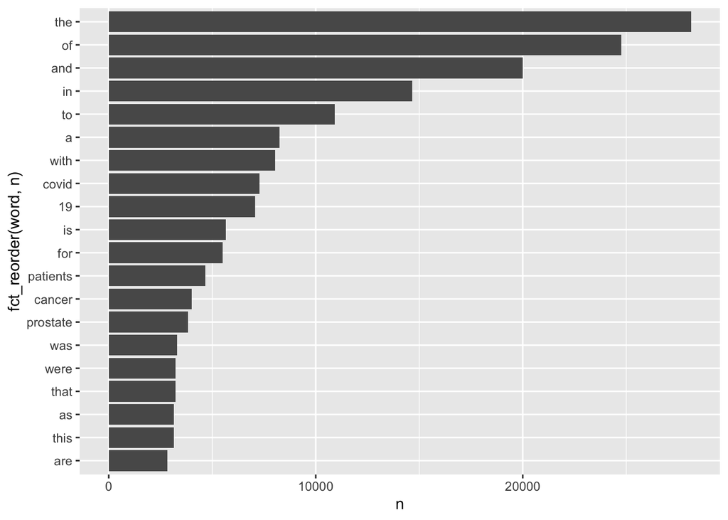

```r
pmsample %>%
  unnest_tokens(word, abstract) %>%
  count(word, sort = TRUE) %>%
  top_n(20, n) %>%
  ggplot(aes(n, fct_reorder(word, n))) +
  geom_col()
```

From the graph, we see that the most frequent words are the stop words, non-specific to article analysis

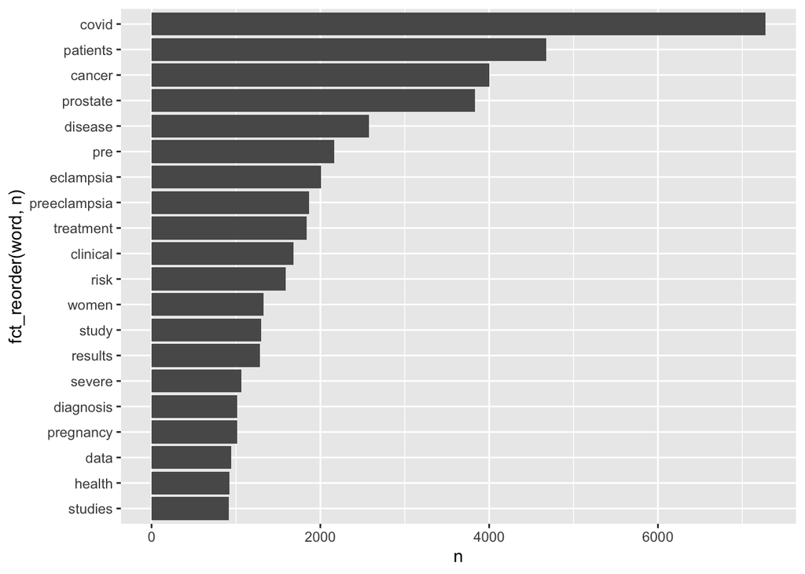

```r
pmsample %>%
  unnest_tokens(word, abstract) %>%
  anti_join(stop_words, by = c("word")) %>%
  count(word, sort = TRUE) %>%
  #use regular expression to avoid numbers
  filter(!grepl(pattern = "^[0-9]+$", x = word)) %>%
  top_n(20, n) %>%
  ggplot(aes(n, fct_reorder(word, n))) +
  geom_col()
```

Removing those stop words let us have a better idea about what the abstracts about. In addition, after removing stop words, the professional term appears the most frequent. The top 5 common tokens are covid, patients, cancer, prostate, and disease.

Tokenize the abstracts into bigrams. Find the 10 most common bigram and visualize them with ggplot2

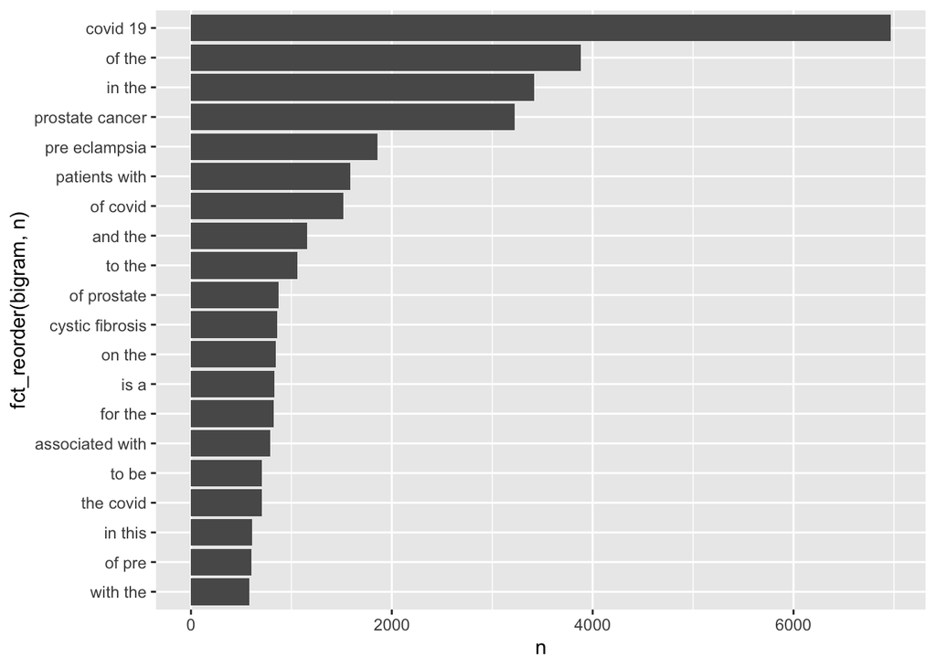

```r
pmsample %>%
  unnest_ngrams(bigram, abstract, n=2) %>%
  count(bigram, sort = TRUE) %>%
  top_n(20, n) %>%
  ggplot(aes(n, fct_reorder(bigram, n))) +
  geom_col()
```

The 10 most common bigram are covid 19, of the, in the, prostate cancer, pre eclampsia, patients with, of covid, and the, to the, and of prostate.

Calculate the TF-IDF value for each word-search term combination

```r
tf_idf <- pmsample %>%
  unnest_tokens(word, abstract) %>%
  count(word, term, sort=TRUE)

tf_idf %>%
   bind_tf_idf(word, term, n) %>%
   arrange(desc(tf_idf)) %>%
   top_n(5)
```

```
##           word            term    n          tf      idf     tf_idf
## 1        covid           covid 7275 0.037105042 1.609438 0.05971826
## 2     prostate prostate cancer 3832 0.031188957 1.609438 0.05019669
## 3    eclampsia    preeclampsia 2005 0.014278389 1.609438 0.02298018
## 4 preeclampsia    preeclampsia 1863 0.013267152 1.609438 0.02135266
## 5   meningitis      meningitis  429 0.009194171 1.609438 0.01479745
```